# HM2: Numerical Optimization for Logistic Regression.

### Name: [Chenxu Wang]

### CWID: [10457625]

## 0. You will do the following:

1. Read the lecture note: [click here](https://github.com/wangshusen/DeepLearning/blob/master/LectureNotes/Logistic/paper/logistic.pdf)
2. Read, complete, and run my code.
3. **Implement mini-batch SGD** and evaluate the performance.
4. Convert the .IPYNB file to .HTML file.
   - The HTML file must contain **the code** and **the output after execution**.
   - Missing **the output after execution** will not be graded.
5. Upload this .HTML file to your Google Drive, Dropbox, or your Github repo. (If you submit the file to Google Drive or Dropbox, you must make the file "open-access". The delay caused by "deny of access" may result in late penalty.)
6. Submit the link to this .HTML file to Canvas.
   - Example: https://github.com/wangshusen/CS583-2020S/blob/master/homework/HM2/HM2.html

## Grading criteria:

1. When computing the `gradient` and `objective function value` using a batch of samples, use **matrix-vector multiplication** rather than a FOR LOOP of **vector-vector multiplications**.
2. Plot `objective function value` against `epochs`. In the plot, compare GD, SGD, and MB-SGD (with $b=8$ and $b=64$). The plot must look reasonable.

# 1. Data processing

- Download the Diabete dataset from https://www.csie.ntu.edu.tw/~cjlin/libsvmtools/datasets/binary/diabetes
- Load the data using sklearn.
- Preprocess the data.

## 1.1. Load the data

```python
from sklearn import datasets
import numpy

x_sparse, y = datasets.load_svmlight_file('diabetes')
x = x_sparse.todense()

print('Shape of x: ' + str(x.shape))
print('Shape of y: ' + str(y.shape))
```

```
Shape of x: (768, 8)
Shape of y: (768,)
```

## 1.2. Partition to training and test sets

```python
# partition the data to training and test sets
n = x.shape[0]
n_train = 640
n_test = n - n_train

rand_indices = numpy.random.permutation(n)
train_indices = rand_indices[0:n_train]
test_indices = rand_indices[n_train:n]

x_train = x[train_indices, :]
x_test = x[test_indices, :]
y_train = y[train_indices].reshape(n_train, 1)
y_test = y[test_indices].reshape(n_test, 1)

print('Shape of x_train: ' + str(x_train.shape))
print('Shape of x_test: ' + str(x_test.shape))
print('Shape of y_train: ' + str(y_train.shape))
print('Shape of y_test: ' + str(y_test.shape))
```

```
Shape of x_train: (640, 8)
Shape of x_test: (128, 8)
Shape of y_train: (640, 1)
Shape of y_test: (128, 1)
```

## 1.3. Feature scaling

Use the standardization to trainsform both training and test features

```python
# Standardization
import numpy

# calculate mu and sig using the training set
d = x_train.shape[1]
mu = numpy.mean(x_train, axis=0).reshape(1, d)
sig = numpy.std(x_train, axis=0).reshape(1, d)

# transform the training features
x_train = (x_train - mu) / (sig + 1E-6)

# transform the test features
x_test = (x_test - mu) / (sig + 1E-6)

print('test mean = ')
print(numpy.mean(x_test, axis=0))

print('test std = ')
print(numpy.std(x_test, axis=0))
```

```
test mean =
[[-0.11053602  0.14649021 -0.04755998  0.10894306  0.22827286  0.22869266
   0.09723059 -0.0763495 ]]
test std =
[[0.9231179  1.19710929 1.03721744 0.99244286 1.26163557 1.07306952
  1.25287102 0.98994977]]
```

## 1.4. Add a dimension of all ones

```python
n_train, d = x_train.shape
x_train = numpy.concatenate((x_train, numpy.ones((n_train, 1))), axis=1)

n_test, d = x_test.shape
x_test = numpy.concatenate((x_test, numpy.ones((n_test, 1))), axis=1)

print('Shape of x_train: ' + str(x_train.shape))
print('Shape of x_test: ' + str(x_test.shape))
```

```
Shape of x_train: (640, 9)
Shape of x_test: (128, 9)
```

# 2. Logistic regression model

The objective function is $Q (w; X, y) = \frac{1}{n} \sum_{i=1}^n \log \Big( 1 + \exp \big( - y_i x_i^T w \big) \Big) + \frac{\lambda}{2} \| w \|_2^2 $.

```python
# Calculate the objective function value
# Inputs:
#     w: d-by-1 matrix
#     x: n-by-d matrix
#     y: n-by-1 matrix
#     lam: scalar, the regularization parameter
# Return:
#     objective function value (scalar)
def objective(w, x, y, lam):
    n, d = x.shape
    yx = numpy.multiply(y, x) # n-by-d matrix
    yxw = numpy.dot(yx, w) # n-by-1 matrix
    vec1 = numpy.exp(-yxw) # n-by-1 matrix
    vec2 = numpy.log(1 + vec1) # n-by-1 matrix
    loss = numpy.mean(vec2) # scalar
    reg = lam / 2 * numpy.sum(w * w) # scalar
    return loss + reg
```

```python
# initialize w
d = x_train.shape[1]
w = numpy.zeros((d, 1))

# evaluate the objective function value at w
lam = 1E-6
objval0 = objective(w, x_train, y_train, lam)
print('Initial objective function value = ' + str(objval0))
```

```
Initial objective function value = 0.6931471805599453
```

# 3. Numerical optimization

## 3.1. Gradient descent

The gradient at $w$ is $g = - \frac{1}{n} \sum_{i=1}^n \frac{y_i x_i }{1 + \exp ( y_i x_i^T w)} + \lambda w$

```python
# Calculate the gradient
# Inputs:
#     w: d-by-1 matrix
#     x: n-by-d matrix
#     y: n-by-1 matrix
#     lam: scalar, the regularization parameter
# Return:
#     g: g: d-by-1 matrix, full gradient
def gradient(w, x, y, lam):
    n, d = x.shape
    yx = numpy.multiply(y, x) # n-by-d matrix
    yxw = numpy.dot(yx, w) # n-by-1 matrix
    vec1 = numpy.exp(yxw) # n-by-1 matrix
    vec2 = numpy.divide(yx, 1+vec1) # n-by-d matrix
    vec3 = -numpy.mean(vec2, axis=0).reshape(d, 1) # d-by-1 matrix
    g = vec3 + lam * w
    return g
```

```python
# Gradient descent for solving logistic regression
# Inputs:
#     x: n-by-d matrix
#     y: n-by-1 matrix
#     lam: scalar, the regularization parameter
#     stepsize: scalar
#     max_iter: integer, the maximal iterations
#     w: d-by-1 matrix, initialization of w
# Return:
#     w: d-by-1 matrix, the solution
#     objvals: a record of each iteration's objective value
def grad_descent(x, y, lam, stepsize, max_iter=100, w=None):
    n, d = x.shape
    objvals = numpy.zeros(max_iter) # store the objective values
    if w is None:
        w = numpy.zeros((d, 1)) # zero initialization

    for t in range(max_iter):
        objval = objective(w, x, y, lam)
        objvals[t] = objval
        print('Objective value at t=' + str(t) + ' is ' + str(objval))
        g = gradient(w, x, y, lam)
        w -= stepsize * g

    return w, objvals
```

Run gradient descent.

```python
lam = 1E-6
stepsize = 1.0
w, objvals_gd = grad_descent(x_train, y_train, lam, stepsize)
```

```
Objective value at t=0 is 0.6931471805599453
Objective value at t=1 is 0.5888042149615449
Objective value at t=2 is 0.5452442110108814
Objective value at t=3 is 0.5217925443441978
Objective value at t=4 is 0.5072307403083615
Objective value at t=5 is 0.49743781607585563
Objective value at t=6 is 0.4905195089011253
Objective value at t=7 is 0.48546666300959695
Objective value at t=8 is 0.4816859261782924
Objective value at t=9 is 0.4788039260101659
Objective value at t=10 is 0.4765740487672644
Objective value at t=11 is 0.4748274181792882
Objective value at t=12 is 0.4734451013361327
Objective value at t=13 is 0.47234142107499993
Objective value at t=14 is 0.47145348403297194
Objective value at t=15 is 0.4707343759563938
Objective value at t=16 is 0.47014861312463174
Objective value at t=17 is 0.46966902929472915
Objective value at t=18 is 0.4692746017264936
Objective value at t=19 is 0.46894890606683315
Objective value at t=20 is 0.46867900093375875
Objective value at t=21 is 0.4684546113691755
Objective value at t=22 is 0.4682675234831319
Objective value at t=23 is 0.46811113048534286
Objective value at t=24 is 0.4679800886600335
Objective value at t=25 is 0.4678700541469277
Objective value at t=26 is 0.46777747977107154
Objective value at t=27 is 0.46769945695260967
Objective value at t=28 is 0.46763359177915764
Objective value at t=29 is 0.4675779071941518
Objective value at t=30 is 0.467530765311996
Objective value at t=31 is 0.46749080536118126
Objective value at t=32 is 0.46745689384700845
Objective value at t=33 is 0.4674280843309151
Objective value at t=34 is 0.4674035848235389
Objective value at t=35 is 0.4673827312395531
Objective value at t=36 is 0.46736496570379144
Objective value at t=37 is 0.46734981875868736
Objective value at t=38 is 0.4673368947231955
Objective value at t=39 is 0.4673258596081331
```

[output cut: 45 more lines]

```
Objective value at t=85 is 0.4672598682845719
Objective value at t=86 is 0.46725985838745926
Objective value at t=87 is 0.4672598498187728
Objective value at t=88 is 0.4672598423991161
Objective value at t=89 is 0.4672598359734796
Objective value at t=90 is 0.46725983040790087
Objective value at t=91 is 0.46725982558658713
Objective value at t=92 is 0.4672598214094343
Objective value at t=93 is 0.4672598177898863
Objective value at t=94 is 0.4672598146530892
Objective value at t=95 is 0.4672598119342987
Objective value at t=96 is 0.46725980957750607
Objective value at t=97 is 0.46725980753425134
Objective value at t=98 is 0.4672598057625999
Objective value at t=99 is 0.467259804226258
```

## 3.2. Stochastic gradient descent (SGD)

Define $Q_i (w) = \log \Big( 1 + \exp \big( - y_i x_i^T w \big) \Big) + \frac{\lambda}{2} \| w \|_2^2 $.

The stochastic gradient at $w$ is $g_i = \frac{\partial Q_i }{ \partial w} = -\frac{y_i x_i }{1 + \exp ( y_i x_i^T w)} + \lambda w$.

```python
# Calculate the objective Q_i and the gradient of Q_i
# Inputs:
#     w: d-by-1 matrix
#     xi: 1-by-d matrix
#     yi: scalar
#     lam: scalar, the regularization parameter
# Return:
#     obj: scalar, the objective Q_i
#     g: d-by-1 matrix, gradient of Q_i
def stochastic_objective_gradient(w, xi, yi, lam):
    d = xi.shape[0]
    yx = yi * xi # 1-by-d matrix
    yxw = float(numpy.dot(yx, w)) # scalar

    # calculate objective function Q_i
    loss = numpy.log(1 + numpy.exp(-yxw)) # scalar
    reg = lam / 2 * numpy.sum(w * w) # scalar
    obj = loss + reg

    # calculate stochastic gradient
    g_loss = -yx.T / (1 + numpy.exp(yxw)) # d-by-1 matrix
    g = g_loss + lam * w # d-by-1 matrix

    return obj, g
```

```python
# SGD for solving logistic regression
# Inputs:
#     x: n-by-d matrix
#     y: n-by-1 matrix
#     lam: scalar, the regularization parameter
#     stepsize: scalar
#     max_epoch: integer, the maximal epochs
#     w: d-by-1 matrix, initialization of w
# Return:
#     w: the solution
#     objvals: record of each iteration's objective value
def sgd(x, y, lam, stepsize, max_epoch=100, w=None):
    n, d = x.shape
    objvals = numpy.zeros(max_epoch) # store the objective values
    if w is None:
        w = numpy.zeros((d, 1)) # zero initialization

    for t in range(max_epoch):
        # randomly shuffle the samples
        rand_indices = numpy.random.permutation(n)
        x_rand = x[rand_indices, :]
        y_rand = y[rand_indices, :]

        objval = 0 # accumulate the objective values
        for i in range(n):
            xi = x_rand[i, :] # 1-by-d matrix
            yi = float(y_rand[i, :]) # scalar
            obj, g = stochastic_objective_gradient(w, xi, yi, lam)
            objval += obj
            w -= stepsize * g

        stepsize *= 0.9 # decrease step size
        objval /= n
        objvals[t] = objval
        print('Objective value at epoch t=' + str(t) + ' is ' + str(objval))

    return w, objvals
```

Run SGD.

```python
lam = 1E-6
stepsize = 0.1
w, objvals_sgd = sgd(x_train, y_train, lam, stepsize)
```

```
Objective value at epoch t=0 is 0.5233315229536548
Objective value at epoch t=1 is 0.5081047227442579
Objective value at epoch t=2 is 0.5086684563189279
Objective value at epoch t=3 is 0.5052699847266726
Objective value at epoch t=4 is 0.4968255285187569
Objective value at epoch t=5 is 0.49977571939960175
Objective value at epoch t=6 is 0.49402968336243536
Objective value at epoch t=7 is 0.4948320602338946
Objective value at epoch t=8 is 0.48887070851529735
Objective value at epoch t=9 is 0.4884674912852064
Objective value at epoch t=10 is 0.48823490080645726
Objective value at epoch t=11 is 0.48543649262036104
Objective value at epoch t=12 is 0.4840525581881323
Objective value at epoch t=13 is 0.4772169189951643
Objective value at epoch t=14 is 0.48015922700114055
Objective value at epoch t=15 is 0.47850397389020005
Objective value at epoch t=16 is 0.4789842501407877
Objective value at epoch t=17 is 0.4764016603027577
Objective value at epoch t=18 is 0.4764877326576955
Objective value at epoch t=19 is 0.47538396600126925
Objective value at epoch t=20 is 0.4744735903359665
Objective value at epoch t=21 is 0.4743376480048774
Objective value at epoch t=22 is 0.47333596052219534
Objective value at epoch t=23 is 0.4730501422836433
Objective value at epoch t=24 is 0.472467445406582
Objective value at epoch t=25 is 0.4720345720323734
Objective value at epoch t=26 is 0.47148144372409123
Objective value at epoch t=27 is 0.4711369943929752
Objective value at epoch t=28 is 0.47095880899259396
Objective value at epoch t=29 is 0.47056643557854827
Objective value at epoch t=30 is 0.47007871037707794
Objective value at epoch t=31 is 0.4697427893868212
Objective value at epoch t=32 is 0.4696343190788565
Objective value at epoch t=33 is 0.46934773817133724
Objective value at epoch t=34 is 0.46900972781038697
Objective value at epoch t=35 is 0.4690391456756573
Objective value at epoch t=36 is 0.46873222681074
Objective value at epoch t=37 is 0.4687087601338285
Objective value at epoch t=38 is 0.4685299303476915
Objective value at epoch t=39 is 0.46842954419405886
```

[output cut: 45 more lines]

```
Objective value at epoch t=85 is 0.4672696288842005
Objective value at epoch t=86 is 0.4672686903184635
Objective value at epoch t=87 is 0.46726784517191355
Objective value at epoch t=88 is 0.46726708371659526
Objective value at epoch t=89 is 0.46726639852517404
Objective value at epoch t=90 is 0.46726578272189634
Objective value at epoch t=91 is 0.46726522767869794
Objective value at epoch t=92 is 0.4672647279172727
Objective value at epoch t=93 is 0.46726427903358125
Objective value at epoch t=94 is 0.4672638743749872
Objective value at epoch t=95 is 0.46726350979402653
Objective value at epoch t=96 is 0.4672631825988439
Objective value at epoch t=97 is 0.4672628878148334
Objective value at epoch t=98 is 0.46726262227338156
Objective value at epoch t=99 is 0.46726238347818666
```

# 4. Compare GD with SGD

Plot objective function values against epochs.

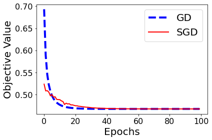

```python
import matplotlib.pyplot as plt
%matplotlib inline

fig = plt.figure(figsize=(6, 4))

epochs_gd = range(len(objvals_gd))
epochs_sgd = range(len(objvals_sgd))

line0, = plt.plot(epochs_gd, objvals_gd, '--b', LineWidth=4)
line1, = plt.plot(epochs_sgd, objvals_sgd, '-r', LineWidth=2)
plt.xlabel('Epochs', FontSize=20)
plt.ylabel('Objective Value', FontSize=20)
plt.xticks(FontSize=16)
plt.yticks(FontSize=16)
plt.legend([line0, line1], ['GD', 'SGD'], fontsize=20)
plt.tight_layout()
plt.show()
fig.savefig('compare_gd_sgd.pdf', format='pdf', dpi=1200)
```

# 5. Prediction

```python
# Predict class label
# Inputs:
#     w: d-by-1 matrix
#     X: m-by-d matrix
# Return:
#     f: m-by-1 matrix, the predictions
def predict(w, X):
    xw = numpy.dot(X, w)
    f = numpy.sign(xw)
    return f
```

```python
# evaluate training error
f_train = predict(w, x_train)
diff = numpy.abs(f_train - y_train) / 2
error_train = numpy.mean(diff)
print('Training classification error is ' + str(error_train))
```

```
Training classification error is 0.21875
```

```python
# evaluate test error
f_test = predict(w, x_test)
diff = numpy.abs(f_test - y_test) / 2
error_test = numpy.mean(diff)
print('Test classification error is ' + str(error_test))
```

```
Test classification error is 0.234375
```

# 6. Mini-batch SGD (fill the code)

## 6.1. Compute the objective $Q_I$ and its gradient using a batch of samples

Define $Q_I (w) = \frac{1}{b} \sum_{i \in I} \log \Big( 1 + \exp \big( - y_i x_i^T w \big) \Big) + \frac{\lambda}{2} \| w \|_2^2 $, where $I$ is a set containing $b$ indices randomly drawn from $\{ 1, \cdots , n \}$ without replacement.

The stochastic gradient at $w$ is $g_I = \frac{\partial Q_I }{ \partial w} = \frac{1}{b} \sum_{i \in I} \frac{- y_i x_i }{1 + \exp ( y_i x_i^T w)} + \lambda w$.

```python
# Calculate the objective Q_I and the gradient of Q_I
# Inputs:
#     w: d-by-1 matrix
#     xi: b-by-d matrix
#     yi: b-by-1 matrix
#     lam: scalar, the regularization parameter
#     b: integer, the batch size
# Return:
#     obj: scalar, the objective Q_i
#     g: d-by-1 matrix, gradient of Q_i
def mb_stochastic_objective_gradient(w, xi, yi, lam, b):
    # Fill the function
    # Follow the implementation of stochastic_objective_gradient
    # Use matrix-vector multiplication; do not use FOR LOOP of vector-vector multiplications

    n,d = xi.shape
    yx = numpy.multiply(yi, xi) # b-by-d matrix
    yxw = numpy.dot(yx, w) # b-by-1 matrix

    # calculate objective function Q_I
    vec = numpy.log(1 + numpy.exp(-yxw)) # b-by-1 matrix
    loss = numpy.mean(vec) # scalar

    reg = lam / 2 * numpy.sum(w * w) # scalar
    obj = loss + reg # scalar

    # calculate MB stochastic gradient
    vec1 = numpy.exp(yxw) # b-by-1 matrix
    vec2 = numpy.divide(yx, 1+ vec1) # b-by-d matrix
    g_loss = - numpy.mean(vec2, axis = 0).reshape(d,1) # d-by-1 matrix
    g = g_loss + lam * w # d-by-1 matrix

    return obj, g
```

## 6.2. Implement mini-batch SGD

Hints:

1. In every epoch, randomly permute the $n$ samples (just like SGD).
2. Each epoch has $\frac{n}{b}$ iterations. In every iteration, use $b$ samples, and compute the gradient and objective using the `mb_stochastic_objective_gradient` function. In the next iteration, use the next $b$ samples, and so on.

```python
# Mini-Batch SGD for solving logistic regression
# Inputs:
#     x: n-by-d matrix
#     y: n-by-1 matrix
#     lam: scalar, the regularization parameter
#     b: integer, the batch size
#     stepsize: scalar
#     max_epoch: integer, the maximal epochs
#     w: d-by-1 matrix, initialization of w
# Return:
#     w: the solution
#     objvals: record of each iteration's objective value
def mb_sgd(x, y, lam, b, stepsize, max_epoch=100, w=None):
    # Fill the function
    # Follow the implementation of sgd
    # Record one objective value per epoch (not per iteration!)

    n, d = x.shape
    objvals = numpy.zeros(max_epoch) # store the objective values
    if w is None:
        w = numpy.zeros((d, 1)) # zero initialization

    for t in range(max_epoch):
        # randomly shuffle the samples
        rand_indices = numpy.random.permutation(n)
        x_rand = x[rand_indices, :]
        y_rand = y[rand_indices, :]

        objval = 0 # accumulate the objective values
        for i in range(0, n, b):
            xi = x_rand[i:i+b, :] # b-by-d matrix
            yi = y_rand[i: i+b, :] # b-by-1 matrix
            obj, g = mb_stochastic_objective_gradient(w, xi, yi, lam, b)
            objval += obj
            w -= stepsize * g

        stepsize *= 0.9 # decrease step size
        objval /= n/b
        objvals[t] = objval
        print('Objective value at epoch t=' + str(t) + ' is ' + str(objval))

    return w, objvals
```

## 6.3. Run MB-SGD

```python
# MB-SGD with batch size b=8
lam = 1E-6 # do not change
b = 8 # do not change
stepsize = 0.1 # you must tune this parameter

w, objvals_mbsgd8 = mb_sgd(x_train, y_train, lam, b, stepsize)
```

```
Objective value at epoch t=0 is 0.5406011587564215
Objective value at epoch t=1 is 0.48160094709510687
Objective value at epoch t=2 is 0.4761699240404157
Objective value at epoch t=3 is 0.47430986666652386
Objective value at epoch t=4 is 0.47238694930193176
Objective value at epoch t=5 is 0.4721233667975664
Objective value at epoch t=6 is 0.47088410283085746
Objective value at epoch t=7 is 0.47091726254631505
Objective value at epoch t=8 is 0.47072921650512844
Objective value at epoch t=9 is 0.4703863799369886
Objective value at epoch t=10 is 0.47020029036427397
Objective value at epoch t=11 is 0.4695588144039159
Objective value at epoch t=12 is 0.4693700515952515
Objective value at epoch t=13 is 0.4694022430868426
Objective value at epoch t=14 is 0.46941608426416515
Objective value at epoch t=15 is 0.46881461426796045
Objective value at epoch t=16 is 0.46885063495559454
Objective value at epoch t=17 is 0.4686311272168213
Objective value at epoch t=18 is 0.46850330178612304
Objective value at epoch t=19 is 0.4684339893457021
Objective value at epoch t=20 is 0.4682783069942424
Objective value at epoch t=21 is 0.4682293948679982
Objective value at epoch t=22 is 0.4682051143903072
Objective value at epoch t=23 is 0.4681314145826955
Objective value at epoch t=24 is 0.46790004170987237
Objective value at epoch t=25 is 0.46790895549303774
Objective value at epoch t=26 is 0.467809031887915
Objective value at epoch t=27 is 0.4677766272065578
Objective value at epoch t=28 is 0.46775052781164134
Objective value at epoch t=29 is 0.467667128414606
Objective value at epoch t=30 is 0.46761520036781246
Objective value at epoch t=31 is 0.4676125757895725
Objective value at epoch t=32 is 0.4675704333659313
Objective value at epoch t=33 is 0.46751053318938646
Objective value at epoch t=34 is 0.46753745178040323
Objective value at epoch t=35 is 0.4674766042417537
Objective value at epoch t=36 is 0.4674422988585344
Objective value at epoch t=37 is 0.4674382893627495
Objective value at epoch t=38 is 0.4674176974305861
Objective value at epoch t=39 is 0.4674009513915872
```

[output cut: 45 more lines]

```
Objective value at epoch t=85 is 0.46726143739831894
Objective value at epoch t=86 is 0.467261402214792
Objective value at epoch t=87 is 0.46726118443780135
Objective value at epoch t=88 is 0.4672610953072662
Objective value at epoch t=89 is 0.4672609797196762
Objective value at epoch t=90 is 0.4672609407783913
Objective value at epoch t=91 is 0.46726079693661954
Objective value at epoch t=92 is 0.46726079535302467
Objective value at epoch t=93 is 0.46726072208943004
Objective value at epoch t=94 is 0.4672606371272668
Objective value at epoch t=95 is 0.4672606097152355
Objective value at epoch t=96 is 0.46726058688939515
Objective value at epoch t=97 is 0.467260560590893
Objective value at epoch t=98 is 0.4672605458030922
Objective value at epoch t=99 is 0.4672604851508602
```

```python
# MB-SGD with batch size b=64
lam = 1E-6 # do not change
b = 64 # do not change
stepsize = 0.1 # you must tune this parameter

w, objvals_mbsgd64 = mb_sgd(x_train, y_train, lam, b, stepsize)
```

```
Objective value at epoch t=0 is 0.6473968867516431
Objective value at epoch t=1 is 0.5819222499122523
Objective value at epoch t=2 is 0.5492834475452286
Objective value at epoch t=3 is 0.5302016912159856
Objective value at epoch t=4 is 0.5180514612974714
Objective value at epoch t=5 is 0.5096620512428801
Objective value at epoch t=6 is 0.5036831257216149
Objective value at epoch t=7 is 0.49918890087086015
Objective value at epoch t=8 is 0.49576129440970373
Objective value at epoch t=9 is 0.4930774188641095
Objective value at epoch t=10 is 0.4907704419842614
Objective value at epoch t=11 is 0.4892320116804731
Objective value at epoch t=12 is 0.48757751462173593
Objective value at epoch t=13 is 0.48629761622386686
Objective value at epoch t=14 is 0.4853197855011947
Objective value at epoch t=15 is 0.48443754290191876
Objective value at epoch t=16 is 0.4836758114949212
Objective value at epoch t=17 is 0.48300550014270377
Objective value at epoch t=18 is 0.4825069304118319
Objective value at epoch t=19 is 0.48201261756735575
Objective value at epoch t=20 is 0.4815905054160018
Objective value at epoch t=21 is 0.4812182166797737
Objective value at epoch t=22 is 0.4809142391267282
Objective value at epoch t=23 is 0.48064400529124224
Objective value at epoch t=24 is 0.4803866776307567
Objective value at epoch t=25 is 0.4802008370693741
Objective value at epoch t=26 is 0.48001252835932495
Objective value at epoch t=27 is 0.47982287692454406
Objective value at epoch t=28 is 0.47966603916186407
Objective value at epoch t=29 is 0.47954173970064273
Objective value at epoch t=30 is 0.47943548775391276
Objective value at epoch t=31 is 0.47932515817671373
Objective value at epoch t=32 is 0.4792196945619187
Objective value at epoch t=33 is 0.47913226315712587
Objective value at epoch t=34 is 0.479059001670763
Objective value at epoch t=35 is 0.478987740776131
Objective value at epoch t=36 is 0.47893290909038316
Objective value at epoch t=37 is 0.478879632523607
Objective value at epoch t=38 is 0.4788291693992103
Objective value at epoch t=39 is 0.47878703076454476
```

[output cut: 45 more lines]

```
Objective value at epoch t=85 is 0.47840496611808814
Objective value at epoch t=86 is 0.47840460110158134
Objective value at epoch t=87 is 0.4784043866620006
Objective value at epoch t=88 is 0.47840416935764907
Objective value at epoch t=89 is 0.4784039272191028
Objective value at epoch t=90 is 0.47840377440643495
Objective value at epoch t=91 is 0.47840355312352106
Objective value at epoch t=92 is 0.47840340733849757
Objective value at epoch t=93 is 0.4784032751951354
Objective value at epoch t=94 is 0.47840312990513134
Objective value at epoch t=95 is 0.4784030145991812
Objective value at epoch t=96 is 0.47840292117398464
Objective value at epoch t=97 is 0.4784028321242103
Objective value at epoch t=98 is 0.47840274284380396
Objective value at epoch t=99 is 0.4784026672783045
```

# 7. Plot and compare GD, SGD, and MB-SGD

You are required to compare the following algorithms:

- Gradient descent (GD)
- SGD
- MB-SGD with b=8
- MB-SGD with b=64

Follow the code in Section 4 to plot `objective function value` against `epochs`. There should be four curves in the plot; each curve corresponds to one algorithm.

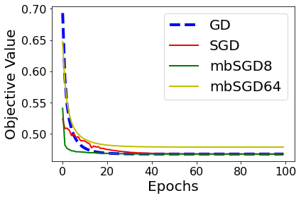

```python
# plot the 4 curves:
import matplotlib.pyplot as plt
%matplotlib inline

fig = plt.figure(figsize=(6, 4))

epochs_gd = range(len(objvals_gd))
epochs_sgd = range(len(objvals_sgd))
epochs_mbsgd8 = range(len(objvals_mbsgd8))
epochs_mbsgd64 = range(len(objvals_mbsgd64))


line0, = plt.plot(epochs_gd, objvals_gd, '--b', LineWidth=4)
line1, = plt.plot(epochs_sgd, objvals_sgd, '-r', LineWidth=2)
line2, = plt.plot(epochs_mbsgd8, objvals_mbsgd8, '-g', LineWidth=2)
line3, = plt.plot(epochs_mbsgd64, objvals_mbsgd64, '-y', LineWidth=2)

plt.xlabel('Epochs', FontSize=20)
plt.ylabel('Objective Value', FontSize=20)
plt.xticks(FontSize=16)
plt.yticks(FontSize=16)
plt.legend([line0, line1, line2, line3], ['GD', 'SGD', "mbSGD8", "mbSGD64"], fontsize=20)
plt.tight_layout()
plt.show()
fig.savefig('compare_gd_sgd.pdf', format='pdf', dpi=1200)
```

1. According to the plot above, the best choice is Mini-batch SGD with cardinality b = 8. Mini-batch SGD would become the best method for optimization if there is a suitable cardinality b.
2. In general, GD is not a good method for training since each epoch will use all of the samples.
3. SGD is the special condition of Mini-batch SGD when the cardinalty b = 1.